# Phase-picker benchmark — Ridgecrest aftershocks

Measures how much of the **analyst-picked** catalog each PhaseNet weight set recovers, on a dense half hour of the 2019 Ridgecrest aftershock sequence. The question driving it: **do the fine-tuned weights recover more S arrivals than the stock models?**

S is the interesting phase. It is the harder pick, it is what constrains depth and location, and it is where the fine-tuning trade-offs show up.

### Why this window

Twenty-one M3.2–4.3 aftershocks in thirty minutes, several separated by only a few seconds, so their waveforms overlap and a picker cannot treat each event as an isolated snippet. The mainshock itself is deliberately excluded — a magnitude 7 ruptures for tens of seconds and buries its own S arrival, which tests something other than picking skill.

### Ground truth, and what it is not

SCEDC analyst picks are the reference. They are authoritative for what they contain, but they are **not exhaustive** — in a sequence this dense no analyst picks every arrival on every station. So:

- **Recall is meaningful.** Of the arrivals a human marked, how many did the model find?
- **Precision is not computable here.** A model pick with no analyst counterpart may be a false positive *or* a real arrival the analyst skipped. This notebook reports those as *extra detections* and never calls them false positives.

Separating those two cases needs either exhaustive re-picking or an association step, neither of which belongs in a benchmark this size.

```python
import io
from collections import defaultdict

import matplotlib.pyplot as plt
import numpy as np
import obspy
import pandas as pd
import seisbench.models as sbm
from obspy import UTCDateTime
from obspy.clients.fdsn import Client
from s3fs import S3FileSystem

%matplotlib inline
```

## 1. Configuration

```python
# --- Benchmark window: 21 aftershocks, M3.2-4.3, several overlapping ---
T0 = UTCDateTime("2019-07-06T05:00:00")
T1 = T0 + 1800                      # 30 minutes
YEAR, DOY = 2019, 187

REGION = dict(minlatitude=35.5, maxlatitude=36.1,
              minlongitude=-117.9, maxlongitude=-117.3)
MIN_MAG = 3.2

# Stations carrying the most analyst picks in this window (network CI)
STATIONS = ["CLC", "WCS2", "MPM", "WBS", "JRC2", "WOR", "TEH", "LRL"]
NETWORK, CHANNEL = "CI", "HH"

# Weight sets to compare. Missing ones are skipped with a message.
WEIGHTS = [
    "quakescope2026",   # v7 fine-tune, this project
    "jma_wc",           # the parent v7 was distilled from
    "original",         # Zhu & Beroza (2019)
    "instance",         # stock baseline
]

P_THRESHOLD = S_THRESHOLD = 0.3
MATCH_TOL = 0.5                     # seconds; a pick counts as recovered within this

# Categorical colors, CVD-validated. Every chart also carries direct value
# labels, which the palette requires and which makes color non-essential.
COLORS = ["#2a78d6", "#eb6834", "#1baf7a", "#eda100"]
```

## 2. Analyst picks from SCEDC

Each event carries `arrivals` that reference `picks`; the arrival supplies the phase label and the pick supplies the time and station.

```python
client = Client("SCEDC")
catalog = client.get_events(
    starttime=T0, endtime=T1, minmagnitude=MIN_MAG,
    includearrivals=True, **REGION,
)
print(f"{len(catalog)} events, M>={MIN_MAG}, in {(T1 - T0) / 60:.0f} minutes")

# analyst[(station, phase)] -> sorted list of UTCDateTime
analyst = defaultdict(list)
origins = []
for ev in catalog:
    o = ev.preferred_origin() or ev.origins[0]
    mag = ev.preferred_magnitude() or ev.magnitudes[0]
    origins.append((o.time, mag.mag))
    by_id = {p.resource_id.id: p for p in ev.picks}
    for arr in o.arrivals:
        pick = by_id.get(arr.pick_id.id)
        if pick is None or not arr.phase:
            continue
        phase = arr.phase[0].upper()          # Pg/Pn -> P, Sg/Sn -> S
        if phase not in ("P", "S"):
            continue
        wid = pick.waveform_id
        if wid.network_code != NETWORK or wid.station_code not in STATIONS:
            continue
        analyst[(wid.station_code, phase)].append(pick.time)

for key in analyst:
    analyst[key] = sorted(analyst[key])

origins.sort()
n_p = sum(len(v) for (_, ph), v in analyst.items() if ph == 'P')
n_s = sum(len(v) for (_, ph), v in analyst.items() if ph == 'S')
print(f"analyst picks on the {len(STATIONS)} benchmark stations: {n_p} P, {n_s} S")
```

```
21 events, M>=3.2, in 30 minutes
analyst picks on the 8 benchmark stations: 125 P, 144 S
```

### How much do these events overlap?

Gaps between consecutive origins, against the ~20–30 s an S coda lasts at these distances. Anything below that means two events share a window.

```
median gap between origins : 56 s
gaps under 30 s            : 5 of 20
shortest gap               : 4 s
```

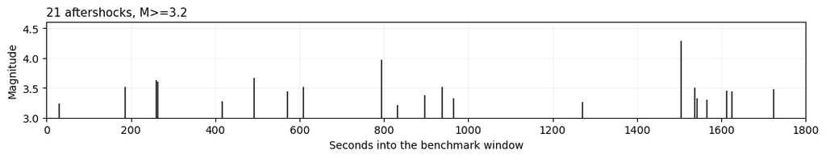

```python
gaps = np.diff([t for t, _ in origins])
print(f"median gap between origins : {np.median(gaps):.0f} s")
print(f"gaps under 30 s            : {(gaps < 30).sum()} of {len(gaps)}")
print(f"shortest gap               : {gaps.min():.0f} s")

fig, ax = plt.subplots(figsize=(11, 2.2))
for t, m in origins:
    ax.vlines(t - T0, 0, m, color='#3d3d3d', lw=1.4)
ax.set_xlim(0, T1 - T0)
ax.set_ylim(3.0, 4.6)
ax.set_xlabel('Seconds into the benchmark window')
ax.set_ylabel('Magnitude')
ax.set_title(f'{len(origins)} aftershocks, M>={MIN_MAG}', fontsize=11, loc='left')
ax.grid(alpha=0.25, lw=0.5)
fig.tight_layout()
plt.show()
```

## 3. Waveforms

One 30-minute window per station from the SCEDC public bucket. Whole-day files are ~20 MB per channel, so this fetches roughly 500 MB the first time and takes a couple of minutes.

```python
def scedc_key(sta, comp, loc=""):
    base = (f"{NETWORK}{sta.ljust(5, '_')}{CHANNEL}{comp}"
            f"{loc.ljust(3, '_')}{YEAR}{DOY:03d}.ms")
    return f"scedc-pds/continuous_waveforms/{YEAR}/{YEAR}_{DOY:03d}/{base}"


fs = S3FileSystem(anon=True)
streams = {}
for sta in STATIONS:
    st = obspy.Stream()
    for comp in "ZNE":
        try:
            with fs.open(scedc_key(sta, comp)) as fh:
                st += obspy.read(io.BytesIO(fh.read()))
        except Exception as exc:
            print(f"  {sta} {comp}: {type(exc).__name__}")
    if len(st) == 0:
        print(f"  {sta}: no data")
        continue
    st.merge(fill_value=0)
    st.trim(T0, T1)
    streams[sta] = st
    print(f"  {sta:<6} {len(st)} traces, {st[0].stats.npts} samples")

print(f"\n{len(streams)}/{len(STATIONS)} stations loaded")
```

```
  CLC    3 traces, 180001 samples
```

```
  WCS2   3 traces, 180001 samples
```

```
  MPM    3 traces, 180001 samples
```

```
  WBS    3 traces, 180001 samples
```

```
  JRC2   3 traces, 180001 samples
```

```
  WOR    3 traces, 180001 samples
```

```
  TEH    3 traces, 180001 samples
```

```
  LRL    3 traces, 180001 samples

8/8 stations loaded
```

## 4. Run each weight set

```python
models = {}
available = sbm.PhaseNet.list_pretrained()
for name in WEIGHTS:
    if name not in available:
        print(f"{name:<16} not installed - skipping")
        continue
    try:
        models[name] = sbm.PhaseNet.from_pretrained(name)
        print(f"{name:<16} loaded")
    except Exception as exc:
        print(f"{name:<16} could not load ({type(exc).__name__}) - skipping")

if not models:
    raise RuntimeError("no weight sets available")

# picks[model][(station, phase)] -> sorted list of UTCDateTime
picks = {name: defaultdict(list) for name in models}
for name, model in models.items():
    for sta, st in streams.items():
        out = model.classify(st, P_threshold=P_THRESHOLD, S_threshold=S_THRESHOLD)
        for p in out.picks:
            picks[name][(sta, p.phase)].append(p.peak_time)
    for key in picks[name]:
        picks[name][key] = sorted(picks[name][key])
    tot_p = sum(len(v) for (_, ph), v in picks[name].items() if ph == 'P')
    tot_s = sum(len(v) for (_, ph), v in picks[name].items() if ph == 'S')
    print(f"{name:<16} {tot_p:4d} P, {tot_s:4d} S")
```

```
quakescope2026   loaded
jma_wc           loaded
original         loaded
instance         loaded
```

```
quakescope2026    530 P,  435 S
```

```
jma_wc            519 P,  448 S
```

```
original          629 P,  710 S
```

```
instance          255 P,  239 S
```

## 5. Match model picks to analyst picks

Greedy nearest-neighbour within the tolerance, each model pick consumed at most once, so two analyst picks cannot both claim the same detection.

```python
def match(analyst_times, model_times, tol=MATCH_TOL):
    """Return (residuals of matched picks, count of unmatched model picks)."""
    used = set()
    residuals = []
    for a in analyst_times:
        best_i, best_d = None, None
        for i, m in enumerate(model_times):
            if i in used:
                continue
            d = m - a
            if abs(d) <= tol and (best_d is None or abs(d) < abs(best_d)):
                best_i, best_d = i, d
        if best_i is not None:
            used.add(best_i)
            residuals.append(best_d)
    return residuals, len(model_times) - len(used)


rows, residual_store = [], {}
for name in models:
    for phase in ("P", "S"):
        n_analyst = n_matched = n_extra = 0
        res_all = []
        for sta in streams:
            a = analyst.get((sta, phase), [])
            m = picks[name].get((sta, phase), [])
            res, extra = match(a, m)
            n_analyst += len(a)
            n_matched += len(res)
            n_extra += extra
            res_all += res
        residual_store[(name, phase)] = res_all
        rows.append(dict(
            weights=name, phase=phase,
            analyst=n_analyst, matched=n_matched,
            recall=round(n_matched / n_analyst, 3) if n_analyst else np.nan,
            MAE=round(float(np.mean(np.abs(res_all))), 3) if res_all else np.nan,
            bias=round(float(np.median(res_all)), 3) if res_all else np.nan,
            extra=n_extra,
        ))

bench = pd.DataFrame(rows)
print(bench.to_string(index=False))
print(f"\nmatch tolerance: +/-{MATCH_TOL} s")
print("recall  = analyst picks recovered / analyst picks")
print("bias    = median (model - analyst); positive means the model picks late")
print("extra   = model picks with no analyst counterpart - NOT false positives,")
print("          the analyst catalog is not exhaustive in a sequence this dense")
```

```
       weights phase  analyst  matched  recall   MAE   bias  extra
quakescope2026     P      125      116   0.928 0.034 -0.012    414
quakescope2026     S      144      114   0.792 0.045 -0.012    321
        jma_wc     P      125      117   0.936 0.030 -0.012    402
        jma_wc     S      144      116   0.806 0.053 -0.032    332
      original     P      125      109   0.872 0.037  0.018    520
      original     S      144      125   0.868 0.056  0.028    585
      instance     P      125       98   0.784 0.036 -0.022    157
      instance     S      144      105   0.729 0.080 -0.062    134

match tolerance: +/-0.5 s
recall  = analyst picks recovered / analyst picks
bias    = median (model - analyst); positive means the model picks late
extra   = model picks with no analyst counterpart - NOT false positives,
          the analyst catalog is not exhaustive in a sequence this dense
```

### S recall, the headline number

Bars carry their values directly, so the comparison does not depend on reading colour.

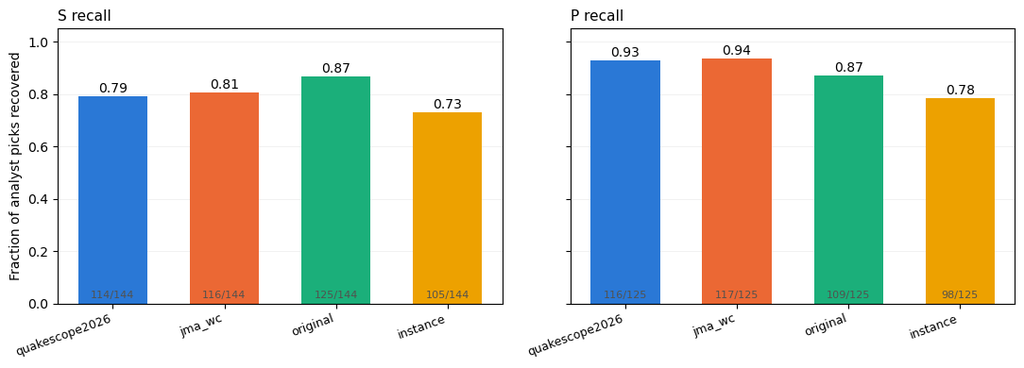

```python
fig, axes = plt.subplots(1, 2, figsize=(11, 4), sharey=True)
names = list(models)
for ax, phase in zip(axes, ('S', 'P')):
    sub = bench[bench.phase == phase].set_index('weights').loc[names]
    bars = ax.bar(range(len(names)), sub['recall'],
                  color=COLORS[:len(names)], width=0.62)
    for i, (v, m) in enumerate(zip(sub['recall'], sub['matched'])):
        ax.text(i, v + 0.015, f'{v:.2f}', ha='center', fontsize=10)
        ax.text(i, 0.02, f'{m}/{sub["analyst"].iloc[i]}', ha='center',
                fontsize=8, color='#52514e')
    ax.set_xticks(range(len(names)))
    ax.set_xticklabels(names, rotation=20, ha='right', fontsize=9)
    ax.set_title(f'{phase} recall', fontsize=11, loc='left')
    ax.grid(alpha=0.25, lw=0.5, axis='y')
    ax.set_axisbelow(True)
axes[0].set_ylabel('Fraction of analyst picks recovered')
axes[0].set_ylim(0, 1.05)
fig.tight_layout()
plt.show()
```

### Timing of the picks that were recovered

Residual is model minus analyst, so negative means the model picks early. Recall and timing trade against each other, and a model that recovers more arrivals by loosening its threshold usually pays for it here.

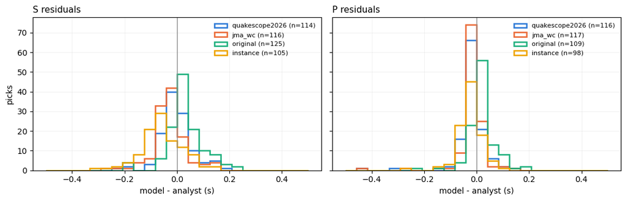

```python
fig, axes = plt.subplots(1, 2, figsize=(11, 3.6), sharey=True)
bins = np.linspace(-MATCH_TOL, MATCH_TOL, 25)
for ax, phase in zip(axes, ('S', 'P')):
    for name, color in zip(names, COLORS):
        res = residual_store[(name, phase)]
        if not res:
            continue
        ax.hist(res, bins=bins, histtype='step', lw=1.8,
                color=color, label=f'{name} (n={len(res)})')
    ax.axvline(0, color='#8a8a8a', lw=1)
    ax.set_title(f'{phase} residuals', fontsize=11, loc='left')
    ax.set_xlabel('model - analyst (s)')
    ax.grid(alpha=0.25, lw=0.5)
    ax.legend(fontsize=8, frameon=False)
axes[0].set_ylabel('picks')
fig.tight_layout()
plt.show()
```

### Per-station S recall

A model that wins on aggregate but collapses at particular stations is a different proposition from one that is uniformly decent.

```python
rows = []
for sta in streams:
    row = {'station': sta, 'analyst_S': len(analyst.get((sta, 'S'), []))}
    for name in names:
        a = analyst.get((sta, 'S'), [])
        m = picks[name].get((sta, 'S'), [])
        res, _ = match(a, m)
        row[name] = round(len(res) / len(a), 2) if a else np.nan
    rows.append(row)
per_sta = pd.DataFrame(rows)
print(per_sta.to_string(index=False))
print("\nvalues are S recall per station")
```

```
station  analyst_S  quakescope2026  jma_wc  original  instance
    CLC         20            0.85    0.85      0.85      0.60
   WCS2         18            0.83    0.83      0.89      0.83
    MPM         18            0.72    0.78      0.78      0.72
    WBS         18            0.72    0.78      0.89      0.72
   JRC2         15            0.87    0.87      0.93      0.80
    WOR         19            0.74    0.79      0.84      0.79
    TEH         18            0.89    0.83      0.89      0.67
    LRL         18            0.72    0.72      0.89      0.72

values are S recall per station
```

## 6. Sensitivity to the matching tolerance

A single tolerance can flatter whichever model happens to sit just inside it, so the ranking should hold as the window widens.

```python
tols = [0.25, 0.5, 1.0, 2.0]
rows = []
for tol in tols:
    row = {'tolerance_s': tol}
    for name in names:
        tot = hit = 0
        for sta in streams:
            a = analyst.get((sta, 'S'), [])
            m = picks[name].get((sta, 'S'), [])
            res, _ = match(a, m, tol=tol)
            tot += len(a)
            hit += len(res)
        row[name] = round(hit / tot, 3) if tot else np.nan
    rows.append(row)
sens = pd.DataFrame(rows)
print(sens.to_string(index=False))
print("\nS recall as a function of match tolerance")
```

```
 tolerance_s  quakescope2026  jma_wc  original  instance
        0.25           0.792   0.799     0.868     0.715
        0.50           0.792   0.806     0.868     0.729
        1.00           0.792   0.806     0.868     0.729
        2.00           0.792   0.806     0.868     0.729

S recall as a function of match tolerance
```

### Export for the consolidated benchmark

Writes the tables above to `docs/benchmark/results/` so that `tutorials/benchmark_summary.ipynb` reads executed output.

```python
# Export the result tables for docs/benchmark/. The consolidated benchmark
# (tutorials/benchmark_summary.ipynb) reads these files rather than numbers
# transcribed from a rendered report, so every figure there traces to an
# executed cell here. Defensive on purpose: a missing table is reported, not fatal.
import datetime as _dt, json as _json
from pathlib import Path as _Path
import seisbench as _sb
_OUT = _Path("../docs/benchmark/results/ridgecrest_aftershocks"); _OUT.mkdir(parents=True, exist_ok=True)
_written = []
def _export(name, obj):
    try:
        (obj.to_csv(_OUT / f"{name}.csv", index=isinstance(obj.index, pd.MultiIndex) or obj.index.name is not None)
         if hasattr(obj, "to_csv") else (_OUT / f"{name}.json").write_text(_json.dumps(obj, indent=1, default=str)))
        _written.append(name)
    except Exception as _exc:
        print(f"{name}: not exported ({type(_exc).__name__}: {_exc})")

_export("recall_at_threshold", bench)
_export("per_station", per_sta)
_export("tolerance_sensitivity", sens)
_meta = dict(notebook="phasenet_aftershock_benchmark.ipynb",
             executed=_dt.datetime.now(_dt.timezone.utc).isoformat(timespec="seconds"),
             seisbench=_sb.__version__,
             config={k: (v if isinstance(v, (int, float, str, list, dict)) else str(v))
                     for k, v in globals().items()
                     if k in ("WEIGHTS", "REPORT_THRESHOLD", "MATCH_TOL", "STATIONS", "T0", "T1",
                              "WINDOW", "MIN_MAG", "THRESHOLD")})
_export("meta", _meta)
print("wrote", ", ".join(_written), "to", _OUT)
```

```
wrote recall_at_threshold, per_station, tolerance_sensitivity, meta to ../docs/benchmark/results/ridgecrest_aftershocks
```

## 7. Reading the result

**S recall** answers the question this benchmark was built for. Compare `quakescope2026` against `instance` for the stock-versus-fine-tuned question, and against `jma_wc` for what the fine-tuning itself changed, since that is the model it was distilled from.

**Extra detections are not errors.** A model with high recall *and* many extra picks may be finding the aftershocks the analysts did not have time to pick — this sequence had hundreds of events per hour. Deciding that needs association: real arrivals line up across stations into locatable events, noise does not. That is the natural follow-on, and QuakeScope already runs PyOcto for it.

**One window, one region, one magnitude band.** Nothing here generalises to teleseismic distances, other networks, or quiet periods. It is a targeted measurement of S recovery under dense overlapping aftershocks, which is a regime that matters for catalog completeness and one where pickers differ sharply.

For the cross-domain benchmark these weights were selected on — and the caveats attached to that selection — see `docs/phasenet_v7_model_description.md`.